# Python语言基础_ch2

### 2.4 字符串（String）

字符串（str）是字符序列，常用于表示文本、编码、标识符等。

字符串的常见定义方法：

- 单引号：`'hello'`
- 双引号：`"hello"`（与单引号等价，常用于字符串里包含单引号）
- 三引号：`'''...'''` 或 `"""..."""`（多行字符串，或包含引号时更方便）
  - 多行注释和多行字符串如何区分？
    - 多行注释通常不赋值给变量，直接写在代码中；多行字符串通常会赋值给变量，或者作为函数的 docstring。

```python
# 字符串举例：

# 不能像列表那样直接修改某个位置的字符
# s = INV1001 # 这行代码会报错，因为 INV1001 没有定义为字符串，应该加上引号
s = 'INV1001'
s = "INV1001"
s = '''INV1001'''  # 这也是一个字符串，包含了换行符

'''INV1001代表关于存货的一个记录ID，
通常用于标识某个特定的存货项目。''' # 这是一个多行注释，用来解释 INV1001 的含义
```

#### 2.4.1 字符串的编码（移至第 5 章）

#### 2.4.2 字符串的常用操作

| 运算符 | 描述 | 实例 |
| --- | --- | --- |
| `+` | 字符串拼接 | `'Hello' + 'World'` -> `'HelloWorld'` |
| `*` | 重复输出字符串 | `'A' * 3` -> `'AAA'` |

```python
# --- 0：准备一个字符串 ---
s = "Life is short, you need Python."
print("original =", s)

# 1. 拼接 (+)
s1 = "Life is short"
s2 = "You need Python"
print(s1 + ", " + s2)

# 2. 重复 (*)
print("-" * 20)
print(s * 3)
print((s+'\n') * 3)

# 3. 成员运算 (in / not in)
print("Li" in s1)
print("Py" not in s1)
```

#### 2.4.3 索引与切片

| 运算符 | 描述 | 实例 |
| --- | --- | --- |
| `[]` | 通过索引获取字符 | `'Hello'[0]` -> `'H'` |
| `[:]` | 截取字符串中的一部分 (切片) | `'Hello'[1:4]` -> `'ell'` |

##### 索引

字符串中的每个字符都有一个对应的索引（index），表示它在字符串中的位置。

- 索引从0开始
- 负数索引表示从末尾开始计数

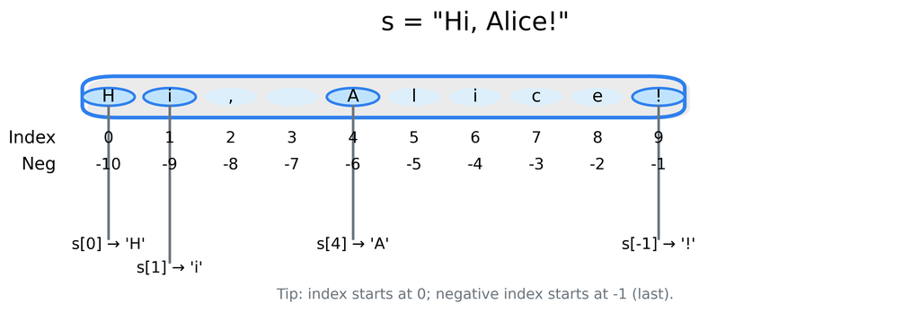

##### 切片

切片（slice）是指从字符串中提取出一个子字符串的操作。

切片基本形式：`s[start:end:step]`

- `start`：起始位置（包含）
- `end`：结束位置（不包含）
- `step`：步长（可省略）
- 左闭右开原则：切片结果包含 `start` 索引对应的字符，但不包含 `end` 索引对应的字符。

  > 勘误：在之前的版本写作“左开右闭”，是不合适的。 但后面的表述“切片结果包含 `start` 索引对应的字符，但不包含 `end` 索引对应的字符”是正确的。

##### 字符串长度

可以使用 `len()` 函数获取字符串的长度（字符数）。

```python
# --- 1：基本信息：长度 / 索引 / 切片 ---
print("len(s) =", len(s))
print("s[0]   =", s[0])      # 第 1 个字符（可能是空格）
print("s[-1]  =", s[-1])     # 最后 1 个字符
print("s[-5:] =", s[-5:])    # 最后 5 个字符
print("s[:10] =", s[:10])    # 前 10 个字符
print("s[2:12]=", s[2:12])   # 索引 2 到 11（左闭右开）
print("s[::-1] =", s[::-1])   # 反转字符串（step = -1）
```

#### 2.4.5 其他常用字符串操作

| 类别 | 常用方法 | 说明 |
| --- | --- | --- |
| 去空格 | `strip`, `lstrip`, `rstrip` | 删除首尾空白 |
| 大小写 | `lower`, `upper`, `title` | 统一文本格式 |
| 查找/计数 | `find`, `count`, `in`, `not in` | 查找位置 / 计数 |
| 判断 | `startswith`, `endswith` | 条件判断 |
| 替换 | `replace` | 替换子串 |
| 拆分与合并 | `split`,`join` | 拆分和合并字符串 |

```python
# --- 2：清洗与大小写：strip / lower / upper / title ---
s_withblank = "  Life is short, you need Python.  "
print("raw string =", s_withblank)
t = s_withblank.strip()        # 去掉首尾空白
print("strip() =", t)
print("lstrip() =", s_withblank.lstrip())  # 去掉左侧空白
print("rstrip() =", s_withblank.rstrip())  # 去掉右侧空白
print("lower() =", t.lower())
print("upper() =", t.upper())
print("title() =", t.title())
```

```python
# --- 3：查找与判断：find / count / startswith / endswith / in ---
print("find('Python') =", t.find("Python"))        # 找不到返回 -1
print("index('Python') =", t.index("Python"))       # 找不到会抛出 ValueError 错误
print("count('o')     =", t.count("o"))            # 统计出现次数
print("startswith('Life') =", t.startswith("Life"))
print("endswith('.')      =", t.endswith("."))
print("'need' in t ?      =", "need" in t)
```

```python
# 若find找不到时，会返回 -1
print("find('Python') =", t.find("Java"))
# 而index找不到时，会抛出 ValueError 错误
print("index('Python') =", t.index("Java"))
# 故而在实际使用中，如果不确定子串是否存在，建议使用 find() 方法来避免程序崩溃；
# 如果需要确保子串一定存在，可以使用 index() 方法，这样如果子串不存在时会立即抛出错误，方便调试和错误处理。
```

```python
# --- 4：替换：replace ---
t2 = t.replace("Python", "SQL")  # replace 会生成新字符串
print("t  =", t)
print("t2 =", t2)
```

```python
# --- 5：拆分与合并：split / join ---
words = t.split()                # 按空白拆分（自动处理多个空格）
print("split() =", words)

joined = " | ".join(words)       # 用分隔符把列表合成字符串
print("join(...) =", joined)
```

> Note: 字符串是不可变对象（immutable），不能对单个字符进行原地修改。所谓“修改字符串”，本质上都是创建一个新字符串。

```python
# 字符串（str）是不可变对象（immutable）
#t[0] = "X"  # ❌ 会报错：TypeError，因为字符串不支持原地修改
new_t = "X" + t[1:]  # ✅ 正确做法：用切片 + 拼接“生成新字符串”
print(new_t)
```

#### 练习：字符串切片

将字符串"uforbgood"赋值到s1变量中  
分别访问s1中的第0个、第3个、第5到8个元素，并将它们组合在一起,并且打印出来.（第0个元素和第3个元素之间要有空格相间，第3个元素和第5-8个元素要有空格相间）

双击阅读参考答案

#### 练习

1. 统计Python之禅前三句有多少个字符。
2. 不包括空格和标点符号， 有多少个字符。
3. 统计Python之禅前三句有多少单词,忽略标点符号 "."

双击阅读参考答案

#### 2.4.6 字符串格式化输出（f-string）

`f"{...}"`: 花括号 `{}` 里不仅可以引用变量，还可以直接写表达式（例如计算、拼接、函数调用等）。

- 引用变量：`f"{name}"`
- 使用表达式：`f"{a+b}"`

```python
# 例子 1：引用变量
name = "Jack"
course = "Python"
print(f"Hello, {name}! Welcome to {course}.")

# 例子 2：在 {} 里写表达式（expression），不仅限于变量名
a = 12
b = 5
# :.2f 表示“保留两位小数”
print(f"a+b = {a+b}, a*b = {a*b}, a/b = {a/b}")
```

#### 练习：使用数字型变量

编写程序，实现如下功能：输入出生年份，输出年龄（简化为2026 - 出生年份）并在屏幕上打印输出：Your age is XX。XX为年龄。

```python
a = int(input('Please enter your birth year (e.g., 2001):')) # int(...) 把输入的字符串转换成整数

b = 2026 - a

#print(...) #请在...中使用格式化输出使得屏幕上打印: Your age is XX. XX为年龄。
```

双击阅读参考答案

#### 2.4.7 转义字符与原始字符串

在字符串字面量（string literal）里，反斜杠 `\` 用来写“转义序列”（escape sequence）：它不是普通字符，而是用来表示一些特殊字符。

- `\n`：换行（newline）
- `\t`：制表符（tab）
- `\\`：一个反斜杠本身（因为单个 `\` 被用作转义开头）
- `\"` / `\'`：在字符串里输出引号（当你需要把引号当作普通字符时）

原始字符串（raw string）：`r"..."`

- 含义：把反斜杠 `\` 当作普通字符保留，不再把它当作转义开头
- 典型用途：Windows 路径、正则表达式（regex）

> Note
> 1. 在代码里如果写 `"C:\temp\new\2026.txt"` 这种“单反斜杠路径”，其中 `\t`、`\n` 可能会被当作转义序列（制表符/换行），打印出来就会“看起来乱码”。
> 2. 更稳妥的写法：`r"C:\temp\new\2026.txt"` 或 `"C:\\temp\\new\\2026.txt"`，也可以用正斜杠 `"C:/temp/new/2026.txt"`。
> 3. raw string 不能以单个反斜杠结尾，例如 `r"C:\temp\"` 会报错（最后的 `\` 会把引号“吃掉”）。

```python
# 转义字符（escape sequence）：\n 换行、\t 制表符
text = "Line1\nLine2"
print(text)            # \n换行

tabbed = "col1\tcol2"
print(tabbed)          # \t制表符

# 路径\t / \n 可能被当作转义，导致显示异常
bad_path = "C:\temp\new\2026.txt"
print("bad_path:", bad_path)

# 更稳妥的写法 1：raw string（原始字符串）—— 反斜杠按字面意思保留
good_path_raw = r"C:\temp\new\2026.txt"

# 更稳妥的写法 2：双反斜杠 —— 把每个 \ 写成 \\
good_path_escaped = "C:\\temp\\new\\2026.txt"

# 更稳妥的写法 3：正斜杠 —— 在很多场景也可以正常工作
good_path_slash = "C:/temp/new/2026.txt"

print("good_path_raw    :", good_path_raw)
print("good_path_escaped:", good_path_escaped)
print("good_path_slash  :", good_path_slash)
```

#### 练习：在字符串中表示特殊字符

1. 在屏幕上打印输出一个类似电脑路径的字符串，如：C:\Users\Jack
2. 在屏幕上输出如下内容："\n" is a line break.

```python
#1

#print('...') # 在...中尝试输出路径 C:\Users\Jack

#2

#print('...') # 在...中尝试输出如下内容 "\n" is a line break.
```

双击阅读参考答案